# Homework 3

The application of logistic regression to examine the predictors of car accidents caused by alcohol consumption

Authors

Nathan Leroy

Michael Pincus

Isaac Tan

# 1. Introduction

Philadelphia has some of the nation’s highest rates of driving fatalities per capita, and alcohol is a primary driver of these deaths. According to the NHTSA, drunk drivers are involved in about 30 percent of all traffic crash fatalities. Beyond the loss of life, the economic impact of alcohol-related crashes has been estimated to be more than $59 billion annually by the CDC.

The goal of this assignment is to use logistic regression to examine which factors make it more likely that alcohol was involved in a car crash in Philadelphia. Our analysis uses a dataset of 53,260 car crashes recorded in the city from 2008-2012. Our dataset includes several independent variables that we think could potentially predict alcohol involvement in a crash:

- Young drivers (16-17 years old): Teenagers may be more likely to make reckless decisions (such as drunk driving) due to less-developed decision-making skills.
- Old drivers (65+ years old): The elderly have reduced motor skills, coordination, and reaction times, which is compounded further by the use of alcohol.
- Aggressive driving: Alcohol reduces inhibitions and impairs judgement, which could lead to people making riskier decisions than they would otherwise.
- Speeding: Alcohol significantly impacts risk perception, which could potentially increase the likelihood of speeding.
- Cell phone usage: Due to impaired risk perception and lowered inhibitions, people may choose to use their phone while driving when they otherwise would not.
- Fatality or major injury: Alcohol impairs reaction time, coordination, and decision-making, which makes it more difficult for the driver to mitigate the severity of a crash.
- Overturned vehicles: Complete loss of vehicle control may be associated with drunk driving; a non-impaired driver could possibly regain control or avoid a complete flip.

We will also examine whether the percentage of residents with at least a bachelor’s degree (`PCTBACHMOR`) and median household income (`MEDHHINC`) are associated with alcohol-related crashes to explore if any neighborhood socioeconomic characteristics are related to the likelihood of alcohol involvement.

For this analysis, we will use R to run a binary logistic regression, measuring the coefficients and statistical significance of each factor to determine which crash types, drivers, and neighborhood characteristics are strongly associated with drunk driving crashes in Philadelphia.

* Because 9,896 crashes occurred in non-residential block groups where we have no data for household income, we removed these from the dataset for the sake of this assignment. Our final dataset has 43,364 crashes.

# 2. Methods

## Issues with OLS Regression and Binary Variables

The dependent variable, `DRINKING_D`, is 1 if a drier in the crash had been drinking and 0 otherwise. Running OLS on a 0/1 outcome gives the linear probability model - its fitted value is read as $P(\text{DRINKING\_D}=1)$, so each coefficient is the change in that probability for a one-unit change in the predictor. This approach has a few issues:

1. Predicted probabilities can’t fall outside $(0,1)$. OLS fits an unbounded straight line. Only 5.7% of our >43,000 crashes involve a drinking driver, so many observations have true probabilities near zero. For crashes with low-risk characteristics, the fitted line can easily drop below 0. Negative probabilities, or probabilities above 1, have no meaning.
2. The linear form is wrong for probabilities. OLS assumes a predictor shifts the probability by the same amount whatever the starting level, but a probability already near 0 or 1 can’t move much further, there’s only two options (0 to 1 and 1 to 0). The true relationship is S-shaped: effects are largest near $p=0.5$ and flatten toward the bounds.
3. The residuals are not normal. For any combination of predictors, a residual can only possibly take two values: $1-\hat{y}$ or $0-\hat{y}$. In this scenario, normality is impossible.

## Logistic Regression

Logistic regression works around the issues in OLS through modeling the log of the odds as a linear function of the predictors, and then converting it back to a probability through the $(0,1)$ bounded logistic function. The model is estimated by a maximum likelihood instead of a least squares estimation. This approach assumes a binomial distribution for $Y$ (either 0 or 1), so it builds in the $p(1-p)$ variance and does not need random residuals.

### Odds and Odds Ratios

Odds compare the probability that an event happens with the probability that it does not happen:

$$\text{Odds}= \frac{p}{1-p}=\frac{\text{\# of occurences}}{\text{\# of non-occurrences}}$$

Probabilities run from 0 to 1, but odds run from 0 to $+\infty$. Odds of 1 mean that the event is equally likely to happen or not happen $p=0.5$. Odds above 1 mean it is more likely to happen or not, and odds below 1 mean that it is less likely to happen than not.

From the cross-tabulation of `SPEEDING` and `DRINKING_D:`

- Crashes involving speeding: 260 had a drinking driver and 1,261 did not. In this case, $\text{Odds} = \frac{260}{1,261} = 0.206$.

An odds ratio (OR) divides the odds in one group by the odds in another:

$$\text{Odds} = \frac{\text{Odds(drinking | speeding)}}{\text{Odds(drinking|no\ speeding)}} = \frac{0.206}{0.056}=3.67$$

In speeding crashes, the odds a driver was drinking was about 3.67 times the odds in non-speeding crashes. This example does not account for the other predictors.

Reading odds ratios:

$OR=1$: the predictor is not associated with the odds of the outcome

$OR>1$: the odds rise, a ratio of 1.25 means that the odds are 25% higher

$OR<1$: the odds fall, a ratio of 0.6 means that the odds are 40% lower

In logistic regression, the $OR$ for a predictor is $e^\beta$, the exponentiated coefficient. It gives the multiplicative change in the odds of $DRINKING\_D=1$ for a one-unit increase in that predictor, holding the other predictors constant. For a binary predictor, a one-unit increase means going from 0 to 1.

### The logit model with multiple predictors

**Logit form:**

$$\begin{aligned}
\ln\left(\frac{p}{1-p}\right) = \beta_0
&+ \beta_1\,\text{FATAL\_OR\_M} + \beta_2\,\text{OVERTURNED} + \beta_3\,\text{CELL\_PHONE} \\
&+ \beta_4\,\text{SPEEDING} + \beta_5\,\text{AGGRESSIVE} + \beta_6\,\text{DRIVER1617} \\
&+ \beta_7\,\text{DRIVER65PLUS} + \beta_8\,\text{PCTBACHMOR} + \beta_9\,\text{MEDHHINC}
\end{aligned}$$

**Logistic form (probability on the left):**

$$p = P(\text{DRINKING\_D} = 1) =
\frac{1}{1 + e^{-\left(
\begin{aligned}
&\beta_0 + \beta_1\,\text{FATAL\_OR\_M} + \beta_2\,\text{OVERTURNED} + \beta_3\,\text{CELL\_PHONE} \\
&+ \beta_4\,\text{SPEEDING} + \beta_5\,\text{AGGRESSIVE} + \beta_6\,\text{DRIVER1617} \\
&+ \beta_7\,\text{DRIVER65PLUS} + \beta_8\,\text{PCTBACHMOR} + \beta_9\,\text{MEDHHINC}
\end{aligned}
\right)}}$$

Where:

$p=P(\text{DRINKING\_D}=1)$: the probability that a crash involved a drinking driver

$\frac{p}{1-p}$: the odds of a drinking driver being involved

$ln(\frac{p}{1-p})$: the log-odds, or logit, of $p$. This is the quantity that is linear in the predictors

$e$: the base of the natural logarithm $(\approx2.718)$

$\beta_0$: the log-odds of drinking-driver involvement when every predictor equals 0. In practice, this typically means that a crash with no fatality or major injury, no overturned vehicle, no cell-phone use, no aggressive driving, no 16-17 or 65+ driver, and `PCTBACHMOR` and `MEDHHINC` both are at 0. $e^{\beta_0}$ is the baseline odds.

$\beta_1\dots\beta_9$: each is the change in the log-odds of `DRINKING_D` = 1 for a one-unit increase in that predictor, holding the others constant. $e^{\beta_i}$ is the corresponding odds ratio. A positive $\beta$ gives $OR>1$ and higher odds. A negative $\beta$ gives $OR<1$ and lower odds.

Neither form has an error term, as the randomness comes from `DRINKING_D` itself, which is Bernoulli-distributed with probability $p$.

[figure not shown]

### The predictors

| Variable | Meaning | Type |
| --- | --- | --- |
| `FATAL_OR_M` | Crash resulted in fatality or major injury | Binary |
| `OVERTURNED` | Crash resulted in an overturned vehicle | Binary |
| `CELL_PHONE` | Driver was using a cell phone | Binary |
| `SPEEDING` | Crash involved speeding | Binary |
| `AGGRESSIVE` | Crash involved aggressive driving | Binary |
| `DRIVER1617` | Crash involved at least one driver aged 16-17 | Binary |
| `DRIVER65PLUS` | Crash involved at least one driver aged 65+ | Binary |
| `PCTBACHMOR` | % of residents with a bachelor’s degree or more, in the crash’s census block group | Continuous |
| `MEDHHINC` | Median household income of the crash’s block group | Continuous |

For a binary predictor, $\beta$ is the difference in log-odds between crashes where the condition is present (1) and absent (0). For example, the coefficient for `SPEEDING` of 1.539 gives $OR=e^{1.539}\approx4.66$. Holding everything else constant, the odds of a drinking driver are about 4.66 times higher in speeding crashes. For the continuous predictors, a “one-unit” change is one percentage point (`PCTBACHMOR`) or one dollar (`MEDHHINC`).

### The logit and logistic functions

The two functions are inverses of each other:

- The logit function, $logit(p)=ln(\frac{p}{1-p})$, takes a probability in $(0,1)$ and stretches it onto the whole real line $(-\infty, +\infty)$. Going from probability to odds removes the upper bound of 1, since odds runs from 0 to $+\infty$. Taking the log removes the lower bound of 0, since log-odds runs from $-\infty$ to $+\infty$. The left-hand side can therefore take any value, just like a linear combination of predictors, so it is valid to set it equal to $\beta_0+\beta_1X_1\dots\beta_9X_9$.
- The logistic function, $p=\frac{1}{1+e^{-z}}$, does the reverse. It takes any value of the linear predictor $z$ and maps it back to a probability strictly between 0 and 1.

### Properties of the logistic function, and why it suits a binary dependent variable

1. It is bounded between 0 and 1. As $z$ approaches $+\infty$, $e^{-z}$ approaches 0 and $p$ approaches 1. It approaches these limits but never reaches them, so every prediction is a valid probability. This directly fixes the problem of working with OLS in this situation.
2. It is S-shaped (sigmoid) and monotonic. As $z$ increases, $p$ always increases. It never reverses direction. The sign of each $\beta$ therefore tells you whether that predictor raises or lowers the probability.
3. Its slope is symmetric around an inflection point at $z=0$, $p=0.5$. It is steepest at $p=0.5$, where log-odds equal zero and odds are equal to 1, and it flattens towards both ends. This matches the behavior of probability: a predictor has its biggest effect when the outcome is uncertain, and little effect once the outcome is almost certain either way.

Together, these properties make the logistic function a natural model for a 0/1 outcome like `DRINKING_D`. It produces valid probabilities, has a realistic S-shaped response based on the way that probability behaves, and its coefficients are interpretable as odds ratios.

### Hypothesis testing for predictors

For each predictor, we use hypothesis testing to determine statistical significance. We begin with the the null hypothesis H₀: that the predictor has no statistically significant relationship with the likelihood of a crash involving a drunk driver. We also have an alternative hypothesis Hₐ: that the predictor has a statistically significant relationship with the likelihood of a crash involving a drunk driver. We test whether we should reject the null hypothesis in favor of the alternative hypothesis or fail to reject the null hypothesis for each individual predictor in our model.

To determine if a parameter is statistically significant or not, we can use the Wald statistic. The Wald statistic is used to determine if an individual regression coefficient is significantly different than zero. It follows a roughly chi-squared distribution with one degree of freedom under the null hypothesis.

The Wald statistic can be calculated using the formula:

$$W=(\frac{\hat{\beta_i}}{SE(\hat{\beta_i})})^2$$
Where:

$\hat{\beta_i}$ = the estimated regression coefficient

$SE(\hat{\beta_i})$ = the standard error of the estimated coefficient

We can use this statistic to calculate a $p$-value; if the $p$-value is less than 0.05, we reject the null hypothesis in favor of the alternative hypothesis, and if the $p$-value is greater than or equal to 0.05, we fail to reject the null hypothesis.

Finally, we can state the coefficient as an odds ratio $OR$, which statisticians generally prefer over raw regression coefficients as it is easier to interpret. Beta coefficients are useful for determining the magnitude and direction of a predictor, but they aren’t intuitive on their own. Odds ratios, on the other hand, describe how a one-unit increase in a predictor increases the odds of a crash involving a drunk driver if all other predictors are held constant.

The formula to calculate the $OR$ is:

$$OR = e^\hat{\beta_i}$$
Where:

$\hat{\beta_i}$= the estimated regression coefficient

An $OR$ of 1 would mean no change in the odds, while an $OR$ of >1 would mean increased odds and an $OR$ <1 would mean decreased odds. For example: if the $OR$ for `SPEEDING` is 2.0, it would mean that crashes involving speeding would have twice the odds of involving an alcohol-impaired driver if all other predictors were held constant.

### Assessing Quality of Model Fit

In OLS regression, $R^2$ is useful and easy to interpret: it is the proportion of variation in the dependent variable explained by the independent variables. We can still calculate $R^2$ in logistic regression; however, it is no longer useful and cannot be interpreted in the same way. Therefore, we need to find other ways to assess the quality of the model fit.

When comparing models, one of the best statistical measures to use is the Akaike Information Criterion (AIC). It evaluates the goodness of fit of the model while penalizing model complexity and excessive parameters. The value of the AIC cannot be interpreted directly for each model, but when compared with the AIC of other candidate models, it can help determine which one is higher quality. Lower AIC means better relative model fit, while higher AIC means worse relative model fit.

When analyzing individual models, we can use three metrics to determine its quality: sensitivity, specificity, and the misclassification rate.

For each crash, logistic regression generates a fitted (predicted) value, $\hat{y}$, by plugging that crash’s predictor values and the estimated coefficients into the logistic equation:

$$\hat{y} = \hat{p} = \frac{1}{1 + e^{-(\hat{\beta}_0 + \hat{\beta}_1\,\text{FATAL\_OR\_M} + \dots + \hat{\beta}_9\,\text{MEDHHINC})}}$$

Unlike in OLS, $\hat{y}$ is not a predicted 0 or 1. It is the model’s estimated probability that the crash involved a drinking driver, $P(\text{DRINKING\_D}=1)$. For example, $\hat{y}=0.85$ means the model estimates an 85 percent probability that a drinking driver was involved.

In a logistic regression model, we either predict that an event will occur (1) or it will not occur (0) based on that predicted probability. A classification cutoff is needed to classify predicted outcomes. It determines what probability we decide will be significant enough to predict that an event will occur. For example, if an event has a 10 percent chance of happening, we would predict the event to not happen with a cutoff of 0.2 and predict it would happen with a cutoff of 0.05.

Since it is extremely difficult to predict an event with 100% accuracy, we will run into two types of errors: false positives and false negatives.

- False positives occur when the model predicts an event to occur, but it actually does not.
- False negatives occur when the model does not predict an event to occur, but it actually does.

|  | **Predicted True** | **Predicted False** |
| --- | --- | --- |
| **Actual True** | TP: True Positive | FN: False Negative |
| **Actual False** | FP: False Positive | TN: True Negative |

Based on the counts of the different classification outcomes, we can then calculate the three performance metrics.

$$\text{sensitivity}=\frac{TP}{(TP+FN)}$$

This measures the proportion of alcohol-related crashes that the model identifies correctly; higher sensitivity is better. For our model, a sensitivity of 0.8 would mean that the model correctly identifies 80 percent of alcohol-related crashes.

$$\text{specificity}=\frac{TN}{(TN+FP)}$$

This measures the proportion of non-alcohol-related crashes the model identifies correctly; higher specificity is better. For our model, a specificity of 0.8 would mean that the model correctly identifies 80 percent of non-alcohol-related crashes.

$$\text{misclassification}=\frac{(FP+FN)}{(TP+TN+FP+FN)}$$

This measures the proportion of all observations that are incorrectly classified by the model. A lower misclassification is better. A rate of 0.8 would mean that 80 percent of crashes are incorrectly classified.

Sensitivity and specificity have an inverse relationship, so we need to find the perfect balance between the two. We can do this by tinkering with the cutoff threshold. A cutoff that is too low makes the model very likely to classify crashes as alcohol-related (high chance of false positives), while a cutoff that is too high is less likely to classify crashes as alcohol-related (high chance of false negatives). Although there’s no way to minimize both false positives and false negatives (besides simply making the model better), we can settle on a reasonable balance after some trial and error.

To see how sensitivity and specificity trade off across every possible cutoff, we can plot a receiver operating characteristic (ROC) curve. The ROC curve plots sensitivity (the true positive rate) on the y-axis against 1 − specificity (the false positive rate) on the x-axis, with one point for each cutoff between 0 and 1. A model that perfectly separates the two groups would pass through the top-left corner (0,1), where sensitivity and specificity both equal 1. A model that performs no better than random guessing would follow the 45-degree diagonal. The more the curve bows toward the top-left corner, the better the model discriminates.

There are several common methods for choosing an “optimal” cutoff from the ROC curve:

- **Youden’s index:** choose the cutoff that maximizes $J = \text{sensitivity} + \text{specificity} - 1$, which is the point on the curve furthest vertically above the diagonal.
- **Minimum distance to the top-left corner:** choose the cutoff whose point on the curve is closest to (0,1), the point of perfect classification.

For this analysis, we use the second method and choose the cutoff that minimizes $d$:

$$d=\sqrt{(1-\text{specificity})^2+(1-\text{sensitivity})^2}$$

Both methods weight sensitivity and specificity equally. In practice, the best cutoff also depends on the relative cost of false positives and false negatives in the specific context.

Finally, we can calculate the area under the ROC curve as a good single-value metric of the model’s performance. The AUC ranges from 0 to 1, with a value 0.5 indicating performance equivalent to random classification. An AUC of 1.0 indicates 100% accuracy. For this analysis, we will use the following interpretations:

| **AUC Value** | **Model Performance** |
| --- | --- |
| 0.9-1.0 | Excellent |
| 0.8-0.9 | Good |
| 0.7-0.8 | Fair |
| 0.6-0.7 | Poor |
| <0.5-0.6 | Fail (worse than random) |

### Assumptions of Logistic Regression

Several of the assumptions in OLS also hold in logistic regression. This includes:

1) The observations must be independent with no clustering or repeated measures

2) There should be no severe multicollinearity among predictors

Additionally, the dependent variable must be binary, and there is a need for a larger sample size as compared to OLS regression as the maximum likelihood estimation (MLE) is used to estimate regression coefficients instead of the least squares method in OLS regression. As such, at least 50 observations per predictor is required. Unlike OLS regression, however, there is no assumption of a linear relationship between the dependent variable and each independent variable as well as the need for homoscedasticity and normal residuals.

### Exploratory Analyses

Before fitting a logistic regression model, it is good practice to explore the relationship between the dependent variable and each candidate predictor individually. These bivariate analyses show whether each predictor appears related to the outcome, whether the direction of that relationship matches what we expect, and whether any variables behave in ways that may complicate the model fitting process.

First, we ran cross-tabulations between each binary predictor (`FATAL_OR_M`, `OVERTURNED`, `SPEEDING`, `AGGRESSIVE`, `DRIVER1617`, and `DRIVER65PLUS`) and the dependent variable (`DRINKING_D`) to produce 2x2 tables of the crash counts. We then compiled the counts and calculated the percentages in a combined table shown in the results section below.

Then, the $\chi^2$ test was then used to determine whether the distribution of one categorical variable varies with respect to the values of another categorical variable. When looking at the cross-tabulations between an individual binary predictor and the dependent variable, the null and alternative hypotheses for the $\chi^2$ test are as follows:

$H_0:$ The proportion of [the binary predictor] for crashes that involve drunk drivers is the same as the proportion of [the binary predictor] for crashes that don’t involve drunk drivers,

$H_a:$ The proportion of [the binary predictor] for crashes that involve drunk drivers is different than the proportion of the [binary predictor for crashes] that don’t involve drunk drivers

From the results, a high value of the $\chi^2$ statistic and a $p$-value lower than 0.05 would suggest that there is sufficient evidence to reject the null hypothesis in favor of the alternative, and that there is an association between drunk driving and the individual predictor.

For continuous variables, our exploratory analysis examined whether the means of the two continuous predictors (`PCTBACHMOR` and `MEDHHINC`) appeared to differ for the different levels of the dependent variable. This was achieved by calculating the group means and standard deviations of both predictors for crashes that involve drunk drivers and crashes that do not involve drunk drivers. To compare the mean value of a continuous variable for two independent groups, the $t$-test is used to assess if the values are statistically significantly different. The null and alternative hypotheses for the independent samples $t$-test were:

$H_0:$ average values of the [continuous variable] are the same for crashes that involve drunk drivers and crashes that do not,

vs.

$H_a:$ average values of the [continuous variable] are different for crashes that involve drunk drivers and crashes that do not.

The higher the value of the $t$-statistic and a $p$ value lower than 0.05 would suggest that there is evidence to reject the null hypothesis in favor of the alternative one. The results of the group means, standard deviations, and $t$-test for each continuous variable were calculated and compiled in a table in the results section below.

# 3. Results

## Results of Exploratory Analysis

Tabulation of the dependent variable:

| `DRINKING_D` | $n$ | % |
| --- | --- | --- |
| 0 = No drinking driver | 40,879 | 94.27 |
| 1 = Drinking driver | 2,485 | 5.73 |
| Total | 43,364 | 100 |

Of the 43,364 crashes in the dataset, 2,485 (5.73%) involved a drinking driver, and other other 40,879 (94.27%) did not. Drunk-driving crashes are a fairly rare event, which affects the analysis in two ways. Firstly, a model that predicts “no alcohol” for every crash would be correct 94% of the time, so overall accuracy alone is not a useful measure of model performance. Second, sensible cut-offs for classifying predicted probabilities will be much lower than 0.5, around the base rate of about 0.057.

### Cross-tabulation with the binary predictors

In the table, $n$ and % give the number and share of crashes in each column where the predictor equals 1. Every test has `df=1`.

| Predictor | No alcohol $n$ (%) | Alcohol $n$ (%) | Total N (%) | $\chi^2$ | $p$ |
| --- | --- | --- | --- | --- | --- |
| `FATAL_OR_M` | 1,181 (2.89) | 188 (7.57) | 1,369 (3.16) | 167.56 | < 0.001 |
| `OVERTURNED` | 612 (1.50) | 110 (4.43) | 722 (1.6 6) | 122.79 | < 0.001 |
| `CELL_PHONE` | 426 (1.04) | 28 (1.13) | 454 (1.05) | 0.16 | 0.687 |
| `SPEEDING` | 1,261 (3.08) | 260 (10.46) | 1,521 (3.51) | 376.78 | < 0.001 |
| `AGGRESSIVE` | 18,522 (45.31) | 916 (36.86) | 19,438 (44.83) | 67.60 | < 0.001 |
| `DRIVER1617` | 674 (1.65) | 12 (0.48) | 686 (1.58) | 20.45 | < 0.001 |
| `DRIVER65PLUS` | 4,237 (10.36) | 119 (4.79) | 4,356 (10.05) | 80.60 | < 0.001 |

For each binary predictor, the $\chi^2$ test checks:

- $H_0$: the predictor and `DRINKING_D` are independent, so the share of crashes with the attribute is the same whether or not a drinking driver was involved.
- $H_a$: the two variables are associated

Six of the seven predictors have $p$-values well below 0.05. For `FATAL_OR_M`, `OVERTURNED`, `SPEEDING`, `AGGRESIVE`, `DRIVER1617`, and `DRIVER65PLUS` we reject $H_0$, and conclude there is a significant association with drunk driving.

- Positive associations: three attributes are much more common alcohol-related crashes. A fatality or major injury occurs in 7.6% of them versus 2.9% of other crashes. An overturned vehicle appears in 4.4% versus 1.5%. Speeding appears in 10.5% versus 3.1%, which is the largest $\chi^2$ statistic (376.78) of all the predictors.
- Negative association: three attributes are less common in alcohol-related crashes. Aggressive driving appears in 36.9% versus 45.3%. A 16-17-year-old driver appears in 0.5% versus 1.6%. A driver aged 65 or older appears in 4.8% versus 10.4%.

Not significant: for `CELL_PHONE` ($\chi^2=0.16$, $p=0.687$), we fail fail to reject $H_0$. Cell-phone use is about equally rare in both groups (1.0% vs. 1.1%), so there is no association with drunk driving in the data.

### Means of the continuous predictors

| Predictor | No alcohol: Mean (SD) | Alcohol: Mean (SD) | $t$ | df | $p$ |
| --- | --- | --- | --- | --- | --- |
| `PCTBACHMOR` | 16.57 (18.21) | 16.61 (18.72) | −0.108 | 2777.5 | 0.914 |
| `MEDHHINC` | $31,483.05 ($16,930.10) | $31,998.75 ($17,810.50) | −1.405 | 2763.9 | 0.160 |

For each continuous predictor, the independent samples t-test checks:

- $H_0$: the mean of the predictor is the same for crashes with and without a drinking driver
- $H_a$: the means differ for crashes with and without a drinking driver

For `PCTBACHMOR`, the average share is almost the same in the two groups: 16.57% for non-alcohol crashes and 16.61% for alcohol crashes. With $p=0.914>0.05$, we fail to reject $H_0$. There is no evidence that neighborhoods educational attainment is associated with drunk-driving crashes.

In multivariate logistic regression, `MEDHHINC` is significant ($p=0.037$) even though the $t$-test is not. This can possibly happen becuse the regression estimates each effect while holding the other predictors constant. In particular, it controls for `PCTBACHMOR`, which is moderately correlated with income ($r=0.48$). The comparison shows why bivariate tests are only a first look and thus do not replace the full model.

## Assumptions of Logistic Regression

Logistic regression assumes independent observations, little to no multicollinearity, no extreme outliers, and a large sample size.

- Our sample size (43,364) is sufficiently large.
- Each observation represents a different crash, so observations can be assumed to be independent.

* One caveat for the independent observations assumption: non-ideal conditions and heavy traffic can increase the likelihood of multiple crashes occurring in the same location or in similar circumstances, which could cause some correlation between the observations.

To test for multicollinearity, we can calculate pairwise Pearson coefficients for all our independent variables:

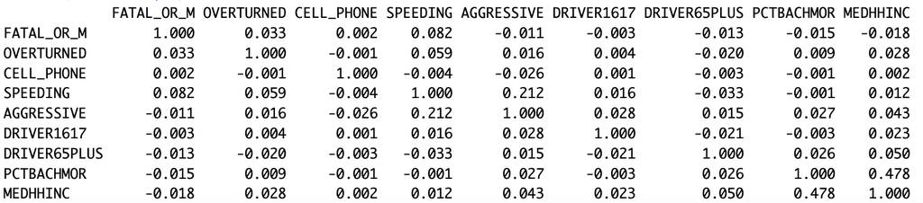

We can also visualize it as a correlation matrix:

[figure not shown]

Note that although Pearson correlations are still effective ways to measure associations in binary predictors, they still have some limitations because they are designed to measure linear relationships between variables.

Additionally, calculating the $VIF$ as an additional test for multicollinearity shows no problematic multicollinearity in any of the independent variables:

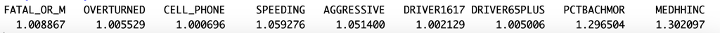

Since $VIF<3$ is generally acceptable, we have no problems with multicollinearity.

## Results of logistic regression

|  | **Estimate** | **Std. Err** | **Z Value** | **p-value** | **OR** | **2.50%** | **97.50%** |
| --- | --- | --- | --- | --- | --- | --- | --- |
| **`FATAL_OR_M`** | 0.8140 | 0.0838 | 9.7130 | <0.001 | 2.26 | 1.91 | 2.65 |
| **`OVERTURNED`** | 0.9289 | 0.1092 | 8.5092 | <0.001 | 2.53 | 2.03 | 3.12 |
| **`CELL_PHONE`** | 0.0296 | 0.1978 | 0.1494 | 0.8812 | 1.03 | 0.68 | 1.49 |
| **`SPEEDING`** | 1.5390 | 0.0805 | 19.1068 | <0.001 | 4.66 | 3.97 | 5.45 |
| **`AGGRESSIVE`** | -0.5969 | 0.0478 | -12.4932 | <0.001 | 0.55 | 0.50 | 0.60 |
| **`DRIVER1617`** | -1.2803 | 0.2931 | -4.3674 | <0.001 | 0.28 | 0.15 | 0.47 |
| **`DRIVER65PLUS`** | -0.7747 | 0.0959 | -8.0814 | <0.001 | 0.46 | 0.38 | 0.55 |
| **`PCTBACHMOR`** | -0.0004 | 0.0013 | -0.2859 | 0.7750 | 1.00 | 1.00 | 1.00 |
| **`MEDHHINC`** | 2.8045x10⁻⁶ | 1.3410x10⁻⁶ | 2.0914 | 0.0365 | 1.00 | 1.00 | 1.00 |

Interpretation of the odds ratios (all effects hold the other predictors constant):

| Predictor | OR (95% CI) | Change in odds | Interpretation |
| --- | --- | --- | --- |
| `FATAL_OR_M` | 2.26 (1.91–2.65) | +126% | Crashes with a fatality or major injury have about 2.26 times the odds of involving a drinking driver. |
| `OVERTURNED` | 2.53 (2.03–3.12) | +153% | Crashes with an overturned vehicle have about 2.53 times the odds of involving a drinking driver. |
| `CELL_PHONE` | 1.03 (0.68–1.49) | +3% | Not significant. The point estimate suggests 3% higher odds, but the CI includes 1, so there is no evidence of an association. |
| `SPEEDING` | 4.66 (3.97–5.45) | +366% | Speeding crashes have about 4.66 times the odds of involving a drinking driver, the strongest effect in the model. |
| `AGGRESSIVE` | 0.55 (0.50–0.60) | −45% | Crashes involving aggressive driving have about 45% lower odds of involving a drinking driver. |
| `DRIVER1617` | 0.28 (0.15–0.47) | −72% | Crashes involving a 16–17-year-old driver have about 72% lower odds of involving a drinking driver. |
| `DRIVER65PLUS` | 0.46 (0.38–0.55) | −54% | Crashes involving a driver aged 65+ have about 54% lower odds of involving a drinking driver. |
| `PCTBACHMOR` | 1.00 (1.00–1.00) | ≈0% | Not significant. Even per 10-point increase in the share of residents with a bachelor’s degree, the OR is about 0.996 (95% CI: 0.971–1.022), so there is effectively no association. |
| `MEDHHINC` | 1.00 (1.00–1.00) | +2.8% per $10,000 | Significant but small. Per $1 the OR rounds to 1.00; per $10,000 increase in block-group median income, the odds of a drinking driver are about 2.8% higher (OR ≈ 1.028, 95% CI: 1.001–1.055). |

*Change in odds = (OR − 1) × 100%.*

Apart from `CELL_PHONE` ($p$=0.881) and `PCTBACHMOR` ($p$=0.775), all other predictors were significant. Of the significant predictors, `SPEEDING` had the strongest association with drunk driving, where the odds that a crash involving a speeding car also involved a drunk driver were about 4.66 times the odds for a crash that did not involve speeding (95% CI: 3.97-5.45). Following the formula of $e^{a_i} * 100\%$, a 1-unit change in `SPEEDING` is associated with a (4.66 - 1) * 100% = 366% increase. `FATAL_OR_M` and `OVERTURNED` were also strongly associated with drunk driving. Crashes resulting in a fatality or major injury had about 2.26 times the odds of involving a drunk driver (95% CI: 1.91-2.65), and crashes involving an overturned vehicle had about 2.53 times the odds (95% CI: 2.03-3.12). These results fit the expectation as the impairment from drunk driving leads to loss of vehicle control and more severe crashes.

Three predictors were associated with lower odds: `AGGRESSIVE` (OR 0.55, 95% CI: 0.50-0.60), `DRIVER1617` (OR 0.28, 95% CI: 0.15-0.47), and `DRIVER65PLUS` (OR 0.46, 95% CI:0.38-0.55). Crashes involving aggressive driving had about 0.55 times the odds of involving a drunk driver (-45%), crashes involving a driver aged 65 and older had about 0.46 times the odds (-54%), and crashes involving a 16 or 17-year old driver had about 0.28 times the odds (-72%).

Of the continuous variables, only `MEDHHINC` was significant (by a smaller margin with $p$=0.0365). However, as income was measured in single dollars, its OR rounds to 1.00. When it is rescaled, a $10,000 increase in block-group median household income would then be associated with about a 2.8% higher odds that a crash involved a drunk driver ($(e^{10,000\times0.000002845}-1)*100\%=2.8\%$)

### Sensitivity, specificity, and misclassification rates

| **Cut Off** | **Sensitivity** | **Specificity** | **Misclassification Rate** |
| --- | --- | --- | --- |
| **0.02†** | **0.984** | **0.058** | **0.889** |
| 0.03 | 0.981 | 0.064 | 0.884 |
| 0.05 | 0.735 | 0.469 | 0.516 |
| 0.07 | 0.221 | 0.914 | 0.126 |
| 0.08 | 0.185 | 0.939 | 0.105 |
| 0.09 | 0.168 | 0.946 | 0.099 |
| 0.1 | 0.164 | 0.948 | 0.097 |
| 0.15 | 0.104 | 0.972 | 0.078 |
| 0.2 | 0.023 | 0.995 | 0.060 |
| **0.5*** | **0.002** | **0.999** | **0.057** |
| † highest misclassification rate, * lowest misclassification rate |  |  |  |

The cut-off that yielded the highest misclassification rate was the 0.02 cut-off with a misclassification rate of 0.889 (Sensitivity 0.984, Specificity 0.058). As nearly every crash is flagged, the sensitivity is high and the specificity is near zero. The cut-off that yielded the lowest classification rate was the 0.50 cut-off with a misclassification rate of 0.057 (Sensitivity 0.002, Specificity 0.999). However, as the sensitivity is near-zero, the cut-off of 0.50 misses many true positive cases as it effectively predicts a false value for all cases.

### Optimal cut-off from the ROC curve

[figure not shown]

The ROC curve plots sensitivity (the true positive rate) against 1-specificity (the false positive rate) for every possible cut-off. A perfect model would reach the top-left corner of the ROC plot (0,1), where sensitivity and specificity both equal 1. The “optimal” cutoff is the point on the curve with the smallest distance to the corner. Note that “optimal” is in quotes, as the true optimal cutoff depends largely on situational context and can vary widely based on it. The distance formula to the top left corner can be read as:

$$d= \sqrt{(1-\text{specificity})^2+(1-\text{sensitivity})^2}$$

For our model, this cut-off is 0.0637 (represented by the red dot on the graph). At this threshold:

- Sensitivity is 0.661. The model correctly flags 66.1% of crashes that actually involved a drinking driver.
- Specificity is 0.545. The model correctly identifies 54.5% of crashes that did not.

This cut-off is very close to the sample’s base rate of drinking-driver crashes, 5.73%. In practice, it classifies a crash as alcohol-related when the model predicts a somewhat higher-than-average probability of a drinking driver.

Comparison with the minimum-misclassification cut-off

| Criterion | Cut-off | Sensitivity | Specificity | Misclassification rate |
| --- | --- | --- | --- | --- |
| Minimum misclassification rate | 0.50 | 0.0016 | 0.9999 | 0.0573 |
| Closest to top-left of ROC curve | 0.0637 | 0.661 | 0.545 | ≈ 0.448 |

The misclassification rate at 0.0637 is calculated from its sensitivity and specificity: $[(1 − 0.545) × 40,879 + (1 − 0.661) × 2,485] / 43,364$.

The two criteria chose very different cut-offs because they optimize different things.

The misclassification rate weights every observation equally. Since 94.3% of the crashes don’t involve alcohol, the lowest rate comes from predicting “no drinking driver” for nearly every crash. At 0.50, only 8 crashes are classified as alcohol-related. The resulting 5.73% error rate is no better than predicting 0 for everyone, and the sensitivity 0.16% makes th model useless for finding drunk-driving crashes.

The ROC criterion gives sensitivity and specificity equal weight. It gives up specificity and accepts a misclassification rate of about 45% in exchange for much higher sensitivity. Missing an alcohol-related crash is arguably more costly than flagging a non-alcohol crash, so the ROC-based cutoff is the more useful choice. The minimum-misclassification cutoff only looks good because as stated previously, so few crashes involve alcohol compared with the rest of the data.

### Area under the curve (AUC)

The area under the curve (AUC) for our model is 0.640. The AUC measures how well the model ranks crashes across all possible cutoffs. It equals the probability that a randomly chosen drinking-driver crash gets a higher predicted probability than a randomly chosen non-drinking crash. An AUC of 0.5 (the straight line on the ROC plot) means the model does no better than chance, and 1.0 means it separates the two groups perfectly.

At 0.640, out model’s predictive accuracy is relatively poor. It does better than chance - in 64% of random alcohol/non-alcohol pairs, the alcohol crash gets the higher predicted probability. However, it cannot reliably tell the two groups apart. This matches the ROC curve, which rises only modestly above the diagonal line. The crash and neighborhood characteristics in the model are significantly associated with drunk driving, but they explain only a small part of which crashes involve a drinking driver. Some important predictors are likely missing from our model, such as time of day, day of the week (such as Friday or Saturday), and the distance of the crash to a bar.

### Summary of Model 2

| Predictor | $\hat{\beta}$ | $p$ | $OR$ |
| --- | --- | --- | --- |
| `FATAL_OR_M` | 0.809 | < 0.001 | 2.246 |
| `OVERTURNED` | 0.940 | < 0.001 | 2.559 |
| `CELL_PHONE` | 0.031 | 0.875 | 1.032 |
| `SPEEDING` | 1.540 | < 0.001 | 4.666 |
| `AGGRESSIVE` | −0.594 | < 0.001 | 0.552 |
| `DRIVER1617` | −1.272 | < 0.001 | 0.280 |
| `DRIVER65PLUS` | −0.766 | < 0.001 | 0.465 |

In comparison with the first model, no predictor changes significance status. The six predictors that were highly significant in Model 1 are still highly significant in Model 2. `CELL_PHONE` is still not significant ($p=0.875$, compared with $p=0.881$ in Model 1. The coefficients and odds ratios barely move. For example the `SPEEDING` odds ratio goes from 4.660 to 4.666, and the `OVERTURNED` odds ratio goes from 2.532 to 2.559.

This stability makes sense, since the binary predictors are almost uncorrelated with `PCTBACHMOR` and `MEDHHINC`, so dropping the two neighborhood variables does not bias the remaining estimates. The only real change is that the effect of `MEDHHINC` is gone, since it is no longer in the model. `MEDHHINC` was the only one of the two dropped variables that was significant in Model 1 ($p=0.037$), `PCTBACHMOR` was not significant ($p=0.775$).

AIC comparison:

| Model | Residual deviance | Parameters | AIC |
| --- | --- | --- | --- |
| Model 1 (all predictors) | 18,340 | 10 | 18359.63 |
| Model 2 (binary only) | 18,344 | 8 | 18360.47 (AIC₁ + 0.84) |

The Akaike Information Criterion is calculated as $-2logL+2k$. It rewards how well a model fits and penalizes it for each extra parameter, and the model with the lower AIC is preferred. Based on this output alone, Model 1 is technically better, but the difference is very slight.

## 4. Discussion

In this assignment, we utilized logistic regression to determine if the chosen factors were significant predictors of accidents related to drunk driving. We first conducted preliminary exploratory analyses on the relationship between the candidate predictors and the dependent variable. Then, we ran a logistic regression model and interpreted the outputs in the results section. Of the predictors, `SPEEDING` was the strongest predictor of alcohol involvement. `FATAL_OR_M` and `OVERTURNED` crashes were also associated with higher odds, while `CELL_PHONE` and `PCTBACHMOR` showed no significant association. Lastly, `MEDHHINC` demonstrated a very weak positive association. We then removed the continuous variables from the model to compare model performance through the AIC, which resulted in a marginal advantage in the Model 1 (the original model) over Model 2.

Most of the results are in line with the expected outcomes. Speeding, rolling over, and more severe crashes are empirically signs of impaired driving, so the positive odds are not surprising. Similarly, the younger and older age factors (16-17 year old range and the 65 and above range) having negative associations also makes sense as these groups are less likely to drive at night and would also drink less. Of all the significant results, the factor of aggressive driving is the most surprising as it was associated with lower odds of drunk driving, though this may be due to how aggression during driving is classified. One likely explanation could be that drunk driving could directly result in more cases of falling asleep at the wheel and more sluggish responses from drivers that may not be captured under the umbrella of aggressive driving. Alternatively, the aggressive driving factor may be capturing more cases of sober but hurried or inattentive driving that would lead to more aggressive vehicle movements by the drivers.

We also considered whether standard logistic regression is appropriate given how rare alcohol-related crashes are, or whether the rare-events methods proposed by Paul Allison would be better suited. Allison argues that the problem with rare events is not the low *percentage* of events, but the small *number* of them: maximum likelihood estimates can be biased when there are few events, even in a large sample. He gives the example that a sample of 100,000 cases with a 2% event rate still has 2,000 events, which is enough for standard logistic regression to work well. In our data, only 5.73% of crashes involved a drinking driver, but that still amounts to 2,485 events, well above Allison’s example. Standard logistic regression is therefore appropriate here, and methods such as Firth’s penalized likelihood are not necessary for the model as a whole. One exception is `DRIVER1617`: only 12 alcohol-related crashes involved a 16–17-year-old driver. Its estimate is less precise, as its wide confidence interval (0.15–0.47) reflects, and it is the one predictor where a rare-events correction could make a noticeable difference.

Some limitations are still present in our analysis. A limitation arising from selection would be the fact that the model only sees crashes, in which the ORs describe which crashes involve alcohol and not the exact causes of the crashes themselves. As alcohol flags depend on police testing and reporting, the events of drunk driving are likely to be undercounted. Furthermore, the weak predictive power of the model (AUC=0.64 and pseudo-R2 = 0.037) means that the model is still missing significant predictors such as the time of day, road type, or speed limits that we could incorporate in to future models to improve predictive performance.